# **Using Transfer Learning to Classify Memes Images**

To extend session google colab:  
https://stackoverflow.com/questions/54057011/google-colab-session-timeout

## **Getting the Data from S3**

https://medium.com/@lily_su/accessing-s3-bucket-from-google-colab-16f7ee6c5b51  
**The structure is:**

- Training
  - Hateful
  - Not_hateful
- Testing
  - Hateful
  - Not_hateful

```python
#!pip install awscli
import awscli
import os
```

```python
# credentials are now here, but will place them in another file. This cell stores credentials in awscli.ini
text = '[default]''
aws_access_key_id = 'AKIAVFMV43NACOFWQJLD'
aws_secret_access_key = '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'
region = 'us-east-2'

'''path = "/content/awscli.ini"
with open(path, 'w') as f:
   f.write(text)
!cat /content/drive/My\ Drive/config/awscli.ini
'''
```

```
  File "<ipython-input-4-b53c75f2c2eb>", line 2
    text = '[default]''
                       ^
SyntaxError: EOL while scanning string literal
```

```python
# load awscli.ini and set as environment variable for the notebook to use
!export AWS_SHARED_CREDENTIALS_FILE=/content/awscli.ini
path = "/content/awscli.ini"
os.environ['AWS_SHARED_CREDENTIALS_FILE'] = path
print(os.environ['AWS_SHARED_CREDENTIALS_FILE'])
```

```
/content/awscli.ini
```

```python
# Load Training and Testing folders from S3 bucket, inside we have a subfolder for each class (0-Not Hateful and 1-Hateful)
#!aws s3 sync s3://capstonedav/Training_small ./Training #1000 images
#!aws s3 sync s3://capstonedav/Testing_small ./Testing #1000 images
```

## **Building a CNN to Classify Memes Image Portion**

Next portion sourced from:  
https://github.com/udacity/deep-learning-v2-pytorch/blob/master/intro-to-pytorch/Part%208%20-%20Transfer%20Learning%20(Solution).ipynb

```python
%matplotlib inline
%config InlineBackend.figure_format = 'retina'

import matplotlib.pyplot as plt

import torch
from torch import nn
from torch import optim
import torch.nn.functional as F
from torchvision import datasets, transforms, models
from torch.utils.data.sampler import SubsetRandomSampler
import numpy as np
```

[output not shown]

### **Creating Data Loaders**

Most of the pretrained models require the input to be 224x224 images. Also, we'll need to match the normalization used when the models were trained. Each color channel was normalized separately, the means are [0.485, 0.456, 0.406] and the standard deviations are [0.229, 0.224, 0.225].

```python
data_dir_training = '/content/Training'
data_dir_testing = '/content/Testing'

##TRY TO OVERFIT###

# TODO: Define transforms for the training data and testing data
# For training we perform Data Augmentation (introduce randomness in the input data itself)
train_transforms = transforms.Compose([transforms.RandomRotation(30),
                                       transforms.RandomResizedCrop(224), #crops 224x224 from the center (check if it is actually resizing)
                                       transforms.RandomHorizontalFlip(), #mirror the image
                                       transforms.ToTensor(),
                                       transforms.Normalize([0.485, 0.456, 0.406],
                                                            [0.229, 0.224, 0.225])])

# For testing we want to use images that aren't altered other than normalizing.
# So, for validation/test images, you'll typically just resize and crop.
test_transforms = transforms.Compose([transforms.Resize(224),
                                      transforms.ToTensor(),
                                      transforms.Normalize([0.485, 0.456, 0.406],
                                                           [0.229, 0.224, 0.225])])

# Pass transforms in here
train_data = datasets.ImageFolder(data_dir_training, transform=train_transforms)
test_data = datasets.ImageFolder(data_dir_testing, transform=test_transforms)

# percentage of training set to use as validation
valid_size = 0.3
batch_size = 64

# obtain test indices that will be used for validation
num_test = len(test_data)
indices = list(range(num_test))
np.random.shuffle(indices)
split = int(np.floor(valid_size * num_test))
test_idx, valid_idx = indices[split:], indices[:split]

# define samplers for obtaining training and validation batches
test_sampler = SubsetRandomSampler(test_idx)
valid_sampler = SubsetRandomSampler(valid_idx)

trainloader = torch.utils.data.DataLoader(train_data, batch_size=batch_size)
validloader = torch.utils.data.DataLoader(train_data, batch_size=batch_size, sampler=valid_sampler)
testloader = torch.utils.data.DataLoader(test_data, batch_size=batch_size, sampler=test_sampler)
```

```python
# chequing data loaders' size
print('training:',len(trainloader)) #1000/64
print('validation:',len(validloader)) #300/64
print('testing:', len(testloader)) #700/64
```

```
training: 36
validation: 7
testing: 15
```

```python
# function to display images from tensors
def imshow(image, ax=None, title=None, normalize=True):
    """Imshow for Tensor."""
    if ax is None:
        fig, ax = plt.subplots()
    image = image.numpy().transpose((1, 2, 0))

    if normalize:
        mean = np.array([0.485, 0.456, 0.406])
        std = np.array([0.229, 0.224, 0.225])
        image = std * image + mean
        image = np.clip(image, 0, 1)

    ax.imshow(image)
    ax.spines['top'].set_visible(False)
    ax.spines['right'].set_visible(False)
    ax.spines['left'].set_visible(False)
    ax.spines['bottom'].set_visible(False)
    ax.tick_params(axis='both', length=0)
    ax.set_xticklabels('')
    ax.set_yticklabels('')

    return ax
```

```
Clipping input data to the valid range for imshow with RGB data ([0..1] for floats or [0..255] for integers).
Clipping input data to the valid range for imshow with RGB data ([0..1] for floats or [0..255] for integers).
Clipping input data to the valid range for imshow with RGB data ([0..1] for floats or [0..255] for integers).
Clipping input data to the valid range for imshow with RGB data ([0..1] for floats or [0..255] for integers).
```

[figure not shown]

```python
# visualize some example images from validation loader
data_iter = iter(trainloader)

images, labels = next(data_iter)
fig, axes = plt.subplots(figsize=(10,4), ncols=4)
for ii in range(4):
    ax = axes[ii]
    imshow(images[ii], ax=ax, normalize=False)
```

```
Clipping input data to the valid range for imshow with RGB data ([0..1] for floats or [0..255] for integers).
```

[figure not shown]

```python
imshow(images[4], normalize=False)
```

### **Loading Densenet and Replacing the Classifier**

We can load in a model such as DenseNet (with 121 hidden layers). This pre-trained neural network can transfer the pattern recognition from ImageNet dataset (features) and only train a new classifier. Let's print out the model architecture so we can see what's going on.

```python
model = models.densenet121(pretrained=True) # 121 hidden layers
#model
```

This model is built out of two main parts, the features and the classifier. The features part is a stack of convolutional layers and overall works as a feature detector that can be fed into a classifier. The classifier part is a single fully-connected layer (classifier): Linear(in_features=1024, out_features=1000). This layer was trained on the ImageNet dataset, so it won't work for our specific problem. That means we need to replace the classifier, but the features will work perfectly on their own. In general, I think about pre-trained networks as amazingly good feature detectors that can be used as the input for simple feed-forward classifiers.

With our model built, we need to train the classifier. However, now we're using a really deep neural network. If you try to train this on a CPU like normal, it will take a long, long time. Instead, we're going to use the GPU to do the calculations. The linear algebra computations are done in parallel on the GPU leading to 100x increased training speeds. It's also possible to train on multiple GPUs, further decreasing training time.

```python
# Use GPU if it's available
device = torch.device("cuda" if torch.cuda.is_available() else "cpu")

# Freeze parameters so we don't backprop through them.
# If requires_grad = True then PyTorch keeps track of operations on a tensor and calculates the gradients
for param in model.parameters():
    param.requires_grad = False

# it is more convenient to build a model with a log-softmax output.
# With log-softmax output you want to use the negative log likehood loss.
# Dim=0, calculates softmax across the rows, so each columns sums to 1
# Dim=1, calculates softmax across the columns, so each row sums to 1.
# In this case each row is one example within the batch, so we use dim=1 to calculate the softmax across each of our examples.
model.classifier = nn.Sequential(nn.Linear(1024, 256),
                                 nn.ReLU(),
                                 nn.Dropout(0.2),
                                 nn.Linear(256, 2),
                                 nn.LogSoftmax(dim=1))

criterion = nn.NLLLoss()
# we could also do:
# criterion = nn.CrossEntropyLoss() but we need the raw output of the network into the loss, not the softmax output.
# This separates the usual criterion = nn.CrossEntropy() into two steps: softmax and NLLLoss,
# and is a useful approach should you want the output of a model to be class probabilities rather than class scores.

# Only train the classifier parameters, feature parameters are frozen
optimizer = optim.Adam(model.classifier.parameters(), lr=0.003)

model.to(device);
```

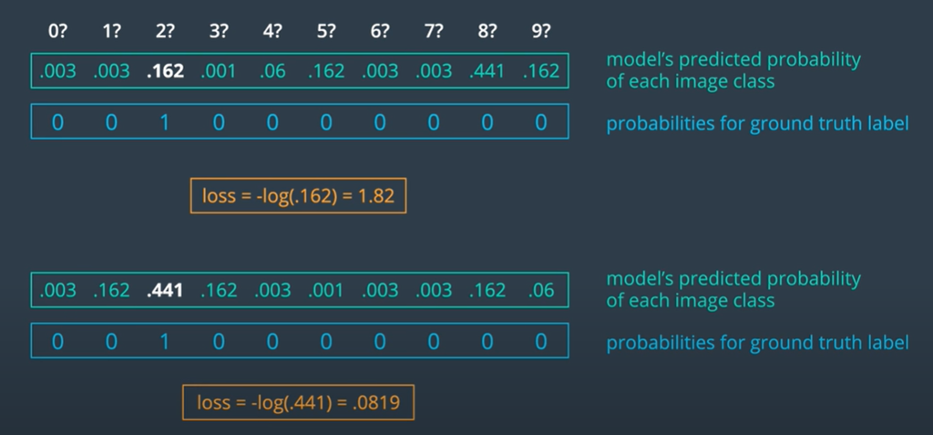

### **Training the Network**

Good theory about backprop, loss function, autograd.

https://github.com/udacity/deep-learning-v2-pytorch/blob/master/intro-to-pytorch/Part%203%20-%20Training%20Neural%20Networks%20(Exercises).ipynb

More notes about epoch, batch size, iterations  
https://towardsdatascience.com/epoch-vs-iterations-vs-batch-size-4dfb9c7ce9c9

```python
epochs = 5
train_losses, valid_losses = [], []
valid_loss_min = np.Inf # set initial "min" to infinity

for epoch in range(epochs):
  # monitor training loss
  train_loss = 0.0
  valid_loss = 0.0

  for inputs, labels in trainloader:
    # Move input and label tensors to the default device
    inputs, labels = inputs.to(device), labels.to(device)

    # clear the gradients
    optimizer.zero_grad()

    logps = model(inputs) # make a forward pass through the network and returns the predicted scores for each class output
    loss = criterion(logps, labels) # use the network output to calculate the loss
    loss.backward() # perform backward pass through the network to calculate the gradients
    optimizer.step() # take a step with the optimizer to update the weights

    train_loss += loss.item() #loss.item() is the averaged loss over the batch
  else:
    test_loss = 0
    accuracy = 0

    # During training we want to use dropout to prevent overfitting, but during inference we want to use the entire network.
    # To do this, use model.eval(). This sets the model to evaluation mode where the dropout probability is 0.
    model.eval()
    with torch.no_grad():
      for inputs, labels in validloader:
          inputs, labels = inputs.to(device), labels.to(device)
          logps = model(inputs)
          batch_loss = criterion(logps, labels)

          valid_loss += batch_loss.item()

          # Calculate accuracy
          # dim=1 takes the sum accross the columns for each row
          # topk(1) returns a tuple of tensors, the first one with the top-1 probability values and the top-1 indices
          # top_class is a 2D tensor with shape (64, 1) while labels is 1D with shape (64), so we reshape
          # 'equals' has binary values, 1 if the prediction matches the actual label and 0 otherwise
          ps = torch.exp(logps)
          top_p, top_class = ps.topk(1, dim=1)
          #print(ps.topk(1, dim=1))
          #print(top_class)
          #print(labels)
          #break
          equals = top_class == labels.view(*top_class.shape)
          accuracy += torch.mean(equals.type(torch.FloatTensor)).item()
    #break
    # collect training and testing losses
    train_losses.append(train_loss/len(trainloader))
    valid_losses.append(valid_loss/len(validloader))

    # save model if validation loss has decreased
    if valid_loss <= valid_loss_min:
      print('Validation loss decreased ({:.6f} --> {:.6f}).  Saving model ...'.format(
      valid_loss_min/len(validloader),
      valid_loss/len(validloader)))
      torch.save(model.state_dict(), 'model.pt')
      valid_loss_min = valid_loss
    else:
      print('Validation loss did not decrease')

    # turn dropout back on by setting the model to train mode with model.train()
    model.train()
  print(f"Epoch {epoch+1}/{epochs}.. "
      f"Train loss: {train_loss/len(trainloader):.3f}.. "
      f"Valid loss: {valid_loss/len(validloader):.3f}.. "
      f"Valid accuracy: {accuracy/len(validloader):.3f}")
```

[output not shown]

```python
labels
```

```
tensor([1, 0, 0, 0, 0, 0, 0, 0, 0, 0, 0, 0, 0, 0, 0, 1, 0, 0, 0, 1, 0],
       device='cuda:0')
```

```python
np.squeeze(equals)
```

```
tensor([ True, False, False, False, False, False, False, False, False, False,
        False, False, False, False, False,  True, False, False, False,  True,
        False], device='cuda:0')
```

```python
equals
```

[output not shown]

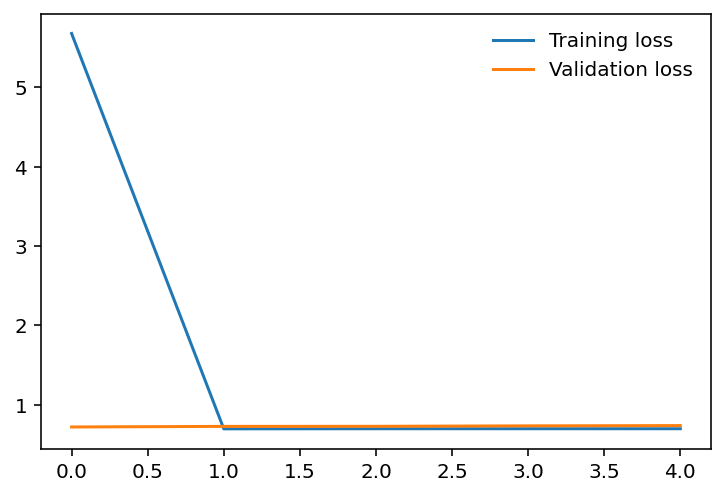

```python
%matplotlib inline
%config InlineBackend.figure_format = 'retina'
import matplotlib.pyplot as plt

plt.plot(train_losses, label='Training loss')
plt.plot(valid_losses, label='Validation loss')
plt.legend(frameon=False)
```

## **Load the Model with the Lowest Validation Loss**

```python
model.load_state_dict(torch.load('model.pt'))
```

```
<All keys matched successfully>
```

## **Test the Trained Network**

```python
# initialize lists to monitor test loss and accuracy
test_loss = 0.0
class_correct = list(0. for i in range(2))
class_total = list(0. for i in range(2))
```

```python
class_correct
```

```
[0.0, 0.0]
```

```python
model.eval() # prep model for evaluation

for inputs, labels in testloader:
  #print(labels)
  #break
  # Move input and label tensors to the default device
  inputs, labels = inputs.to(device), labels.to(device)
  # forward pass: compute predicted outputs by passing inputs to the model
  output = model.forward(inputs)
  #print(output)
  # calculate the loss
  loss = criterion(output, labels)
  # update test loss
  test_loss += loss.item()*inputs.size(0)
  # convert output probabilities to predicted class
  _, pred = torch.max(output, 1)
  # compare predictions to true label
  correct = np.squeeze(pred.eq(labels.data.view_as(pred)))

  #############
  ps = torch.exp(output)
  top_p, top_class = ps.topk(1, dim=1)
  equals = top_class == labels.view(*top_class.shape)
  #############
  # calculate test accuracy for each object class
  for i in range(len(labels)):
      label = labels.data[i]
      class_correct[label] += correct[i].item()
      class_total[label] += 1

# calculate and print avg test loss
test_loss = test_loss/len(testloader.sampler)
print('Test Loss: {:.6f}\n'.format(test_loss))
```

```
Test Loss: 0.756405
```

```python
labels
```

```
tensor([1, 1, 0, 0, 1, 0, 0, 0, 1, 0, 1, 1, 1, 1, 1, 1, 0, 0, 1, 1, 0, 1, 1, 0,
        0, 0, 1, 0, 1, 1, 0, 1, 0, 1, 0, 1, 0, 0, 1, 1, 0, 0, 1, 1, 1, 1, 1, 0,
        1, 0, 0, 1, 0, 0, 0, 1, 1, 1, 1, 1], device='cuda:0')
```

```python
equals = np.squeeze(equals)
equals
```

```
tensor([ True,  True, False, False,  True, False, False, False,  True, False,
         True,  True,  True,  True,  True,  True, False, False,  True,  True,
        False,  True,  True, False, False, False,  True, False,  True,  True,
        False,  True, False,  True, False,  True, False, False,  True,  True,
        False, False,  True,  True,  True,  True,  True, False,  True, False,
        False,  True, False, False, False,  True,  True,  True,  True,  True],
       device='cuda:0')
```

```python
class_correct_juli = list(0. for i in range(2))
class_correct_juli
```

```
[0.0, 0.0]
```

```python
for i in range(len(labels)):
  if (equals[i].item()):
    #class_correct_juli[]
    print(labels[i])
```

[output not shown]

```python
for i in range(2):
    if class_total[i] > 0:
        print('Test Accuracy of %5s: %2d%% (%2d/%2d)' % (
            str(i), 100 * class_correct[i] / class_total[i],
            np.sum(class_correct[i]), np.sum(class_total[i])))
    else:
        print('Test Accuracy of %5s: N/A (no training examples)' % (classes[i]))

print('\nTest Accuracy (Overall): %2d%% (%2d/%2d)' % (
    100. * np.sum(class_correct) / np.sum(class_total),
    np.sum(class_correct), np.sum(class_total)))
```

```
Test Accuracy of     0:  0% ( 0/341)
Test Accuracy of     1: 100% (359/359)

Test Accuracy (Overall): 51% (359/700)
```